# Assignment 01 - Data Viz and Wrangling

```r
library(data.table)
library(leaflet)
library(tidyverse)
library(ggplot2)
library(lubridate)
```

- Download process was done without R and thus is not shown here.

```r
indiv <- data.table(read.csv("chs_individual.csv"))
region <- data.table(read.csv("chs_regional.csv"))

merged <- merge(x = indiv, y = region, by = "townname",  all.x = TRUE, all.y = FALSE)

nrow(indiv)
```

```
## [1] 1200
```

```r
nrow(merged)
```

```
## [1] 1200
```

```r
merged[, bmi_avg := mean(bmi, na.rm = TRUE), by = .(male, hispanic)]
merged[, fev_avg := mean(fev, na.rm = TRUE), by = .(male, hispanic)]

merged[, bmi := ifelse(is.na(bmi), bmi_avg, bmi)]
merged[, fev := ifelse(is.na(fev), fev_avg, fev)]
```

- Missing values in asthma cannot be dealt with using the provided method because asthma is a binary variable.

```r
merged[bmi <= 14, obesity_level := "underweight"]
merged[bmi <= 22 & bmi > 14, obesity_level := "normal"]
merged[bmi <= 24 & bmi > 22, obesity_level := "overweight"]
merged[bmi > 24, obesity_level := "obese"]

merged %>%
  group_by(obesity_level) %>%
    summarise(min = min(bmi), max = max(bmi), n())
```

```
## # A tibble: 4 x 4
##   obesity_level   min   max `n()`
##   <chr>         <dbl> <dbl> <int>
## 1 normal         14.0  22.0   975
## 2 obese          24.0  41.3   103
## 3 overweight     22.0  24.0    87
## 4 underweight    11.3  14.0    35
```

```r
merged[smoke == 1 & gasstove ==1, smoke_gas_exposure := "both"]
merged[smoke == 1 & gasstove ==0, smoke_gas_exposure := "smoke"]
merged[smoke == 0 & gasstove ==1, smoke_gas_exposure := "gas"]
merged[smoke == 0 & gasstove ==0, smoke_gas_exposure := "neither"]
```

```r
merged %>%
  group_by(townname) %>%
    summarise(avg_fev = mean(fev), sd_fev = sd(fev), prop_as = mean(asthma, na.rm = TRUE), sd_as = sd(asthma, na.rm = TRUE))
```

```
## # A tibble: 12 x 5
##    townname      avg_fev sd_fev prop_as sd_as
##    <chr>           <dbl>  <dbl>   <dbl> <dbl>
##  1 Alpine          2087.   291.   0.113 0.319
##  2 Atascadero      2076.   324.   0.255 0.438
##  3 Lake Elsinore   2039.   304.   0.126 0.334
##  4 Lake Gregory    2085.   320.   0.152 0.360
##  5 Lancaster       2003.   317.   0.165 0.373
##  6 Lompoc          2034.   351.   0.113 0.319
##  7 Long Beach      1986.   319.   0.135 0.344
##  8 Mira Loma       1985.   325.   0.158 0.367
##  9 Riverside       1990.   278.   0.11  0.314
## 10 San Dimas       2027.   319.   0.172 0.379
## 11 Santa Maria     2026.   312.   0.134 0.342
## 12 Upland          2024.   343.   0.121 0.328
```

```r
merged %>%
  group_by(male) %>%
    summarise(avg_fev = mean(fev), sd_fev = sd(fev), prop_as = mean(asthma, na.rm = TRUE), sd_as = sd(asthma, na.rm = TRUE))
```

```
## # A tibble: 2 x 5
##    male avg_fev sd_fev prop_as sd_as
##   <int>   <dbl>  <dbl>   <dbl> <dbl>
## 1     0   1959.   312.   0.121 0.326
## 2     1   2104.   308.   0.173 0.378
```

```r
merged %>%
  group_by(obesity_level) %>%
    summarise(avg_fev = mean(fev), sd_fev = sd(fev), prop_as = mean(asthma, na.rm = TRUE), sd_as = sd(asthma, na.rm = TRUE))
```

```
## # A tibble: 4 x 5
##   obesity_level avg_fev sd_fev prop_as sd_as
##   <chr>           <dbl>  <dbl>   <dbl> <dbl>
## 1 normal          2000.   295.  0.140  0.347
## 2 obese           2266.   325.  0.21   0.409
## 3 overweight      2224.   317.  0.165  0.373
## 4 underweight     1698.   303.  0.0857 0.284
```

```r
merged %>%
  filter(!(smoke_gas_exposure %in% NA)) %>%
    group_by(smoke_gas_exposure) %>%
      summarise(avg_fev = mean(fev), sd_fev = sd(fev), prop_as = mean(asthma, na.rm = TRUE), sd_as = sd(asthma, na.rm = TRUE))
```

```
## # A tibble: 4 x 5
##   smoke_gas_exposure avg_fev sd_fev prop_as sd_as
##   <chr>                <dbl>  <dbl>   <dbl> <dbl>
## 1 both                 2020.   299.   0.130 0.338
## 2 gas                  2026.   318.   0.148 0.355
## 3 neither              2055.   330.   0.148 0.356
## 4 smoke                2056.   296.   0.171 0.382
```

Looking at the data (EDA)

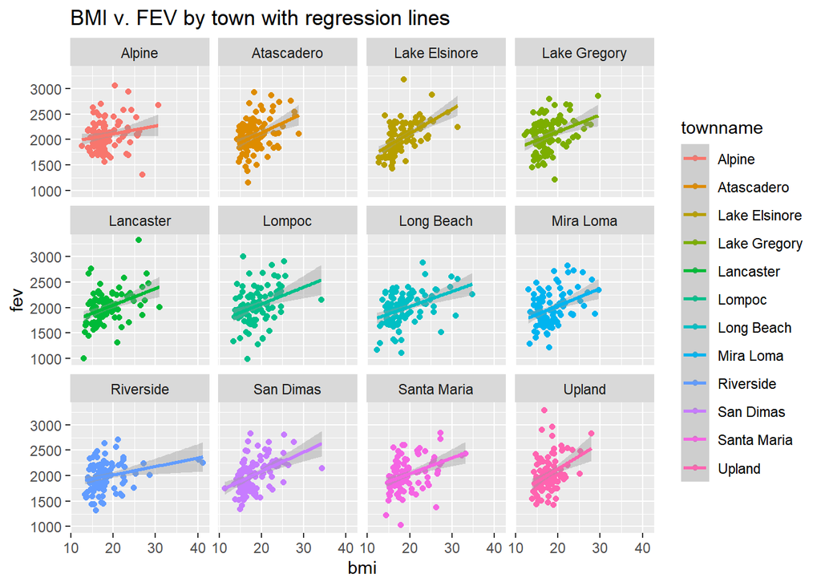

```r
merged %>%
  ggplot(mapping = aes(x=bmi, y=fev, color=townname))+
  geom_point()+
  stat_smooth(method=lm)+
  facet_wrap(~townname)+
  labs(title = "BMI v. FEV by town with regression lines")
```

- BMI and FEV have positive correlation across all towns.

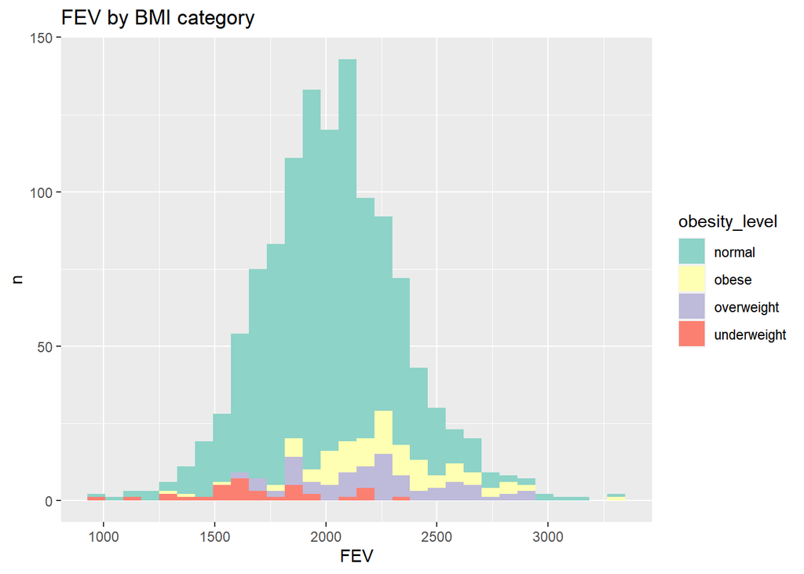

```r
merged %>%
  ggplot()+
  geom_histogram(mapping = aes(x=fev, fill=obesity_level))+
  scale_fill_brewer(palette = "Set3")+
  labs(title = "FEV by BMI category", x="FEV", y="n")
```

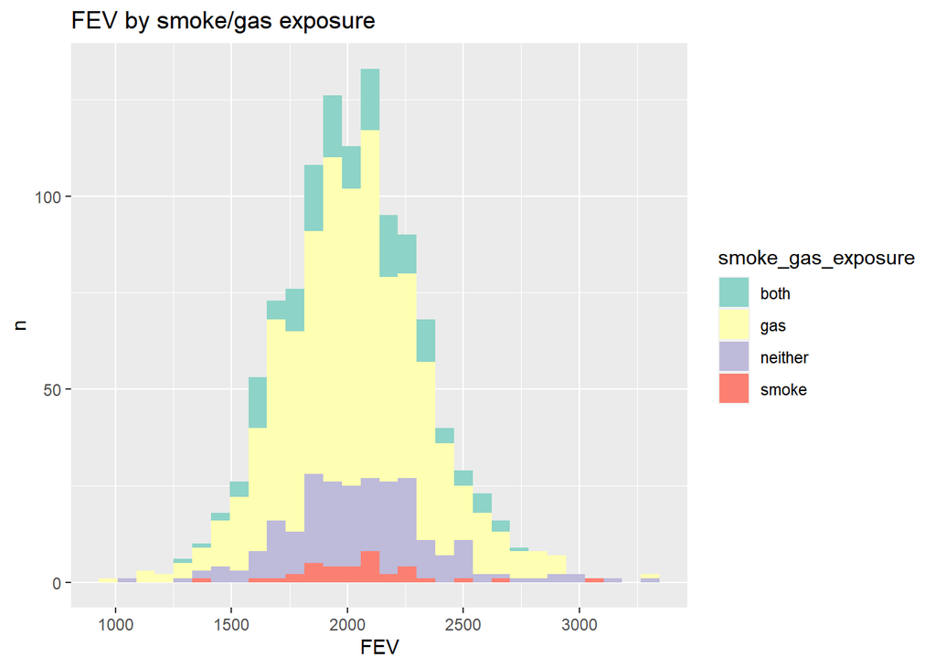

```r
merged %>%
  filter(!(smoke_gas_exposure %in% NA)) %>%
    ggplot()+
    geom_histogram(mapping = aes(x=fev, fill=smoke_gas_exposure))+
    scale_fill_brewer(palette = "Set3")+
    labs(title = "FEV by smoke/gas exposure", x="FEV", y="n")
```

- Within each category of obesity level or smoke/gas exposure, the distribution of FEV is nearly normal. Most people have normal BMI and exposure to gas.

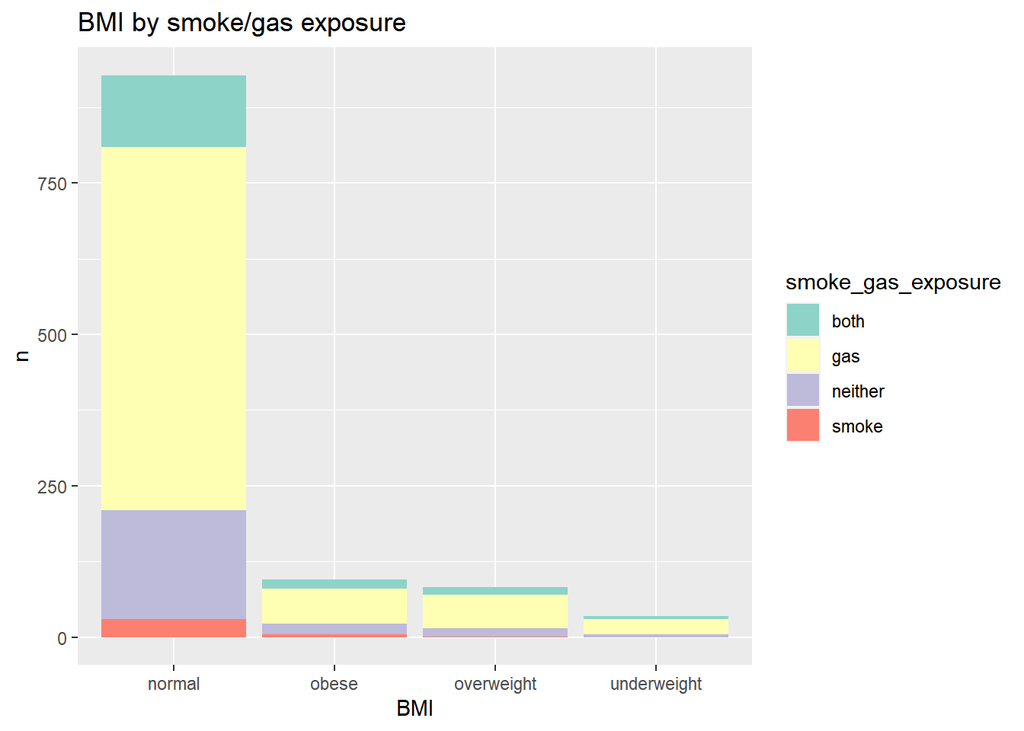

```r
merged %>%
  filter(!(smoke_gas_exposure %in% NA)) %>%
  ggplot()+
  geom_bar(mapping = aes(x=obesity_level, fill=smoke_gas_exposure))+
  scale_fill_brewer(palette = "Set3")+
  labs(title = "BMI by smoke/gas exposure", x="BMI", y="n")
```

- Again, lots of people have normal BMI and exposure to gas.

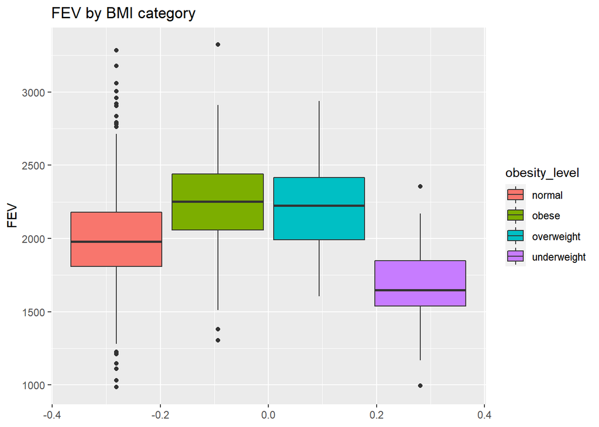

```r
merged %>%
  ggplot() +
  geom_boxplot(mapping = aes(y=fev, fill=obesity_level))+
  labs(title = "FEV by BMI category", y="FEV")
```

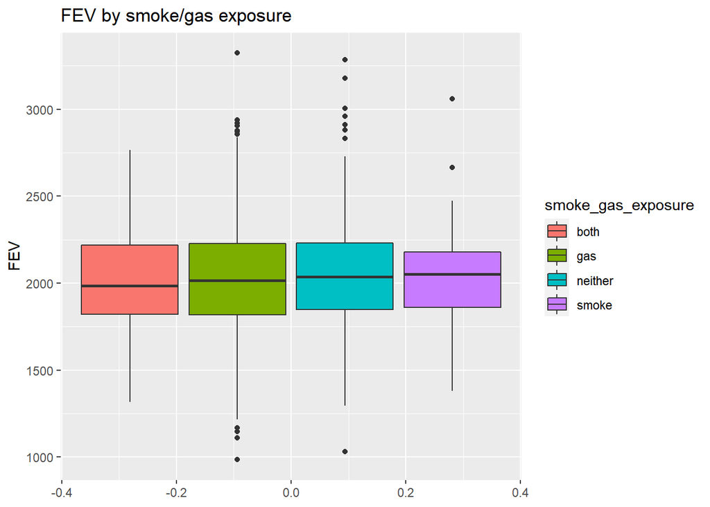

```r
merged %>%
    filter(!(smoke_gas_exposure %in% NA)) %>%
      ggplot() +
      geom_boxplot(mapping = aes(y=fev, fill=smoke_gas_exposure))+
      labs(title = "FEV by smoke/gas exposure", y="FEV")
```

- FEV again shows positive correlation with BMI but no clear correlation with gas/smoke exposure.

```r
leaflet(merged) %>%
  addProviderTiles('OpenStreetMap') %>%
  addCircles(lat = ~lat, lng = ~lon, color = "brown",opacity = 1,
             fillOpacity = 1, radius = ~(pm25_mass*200))
```

[interactive chart not shown]

- PM2.5 mass is higher in greater LA area than in other Southern California communities.

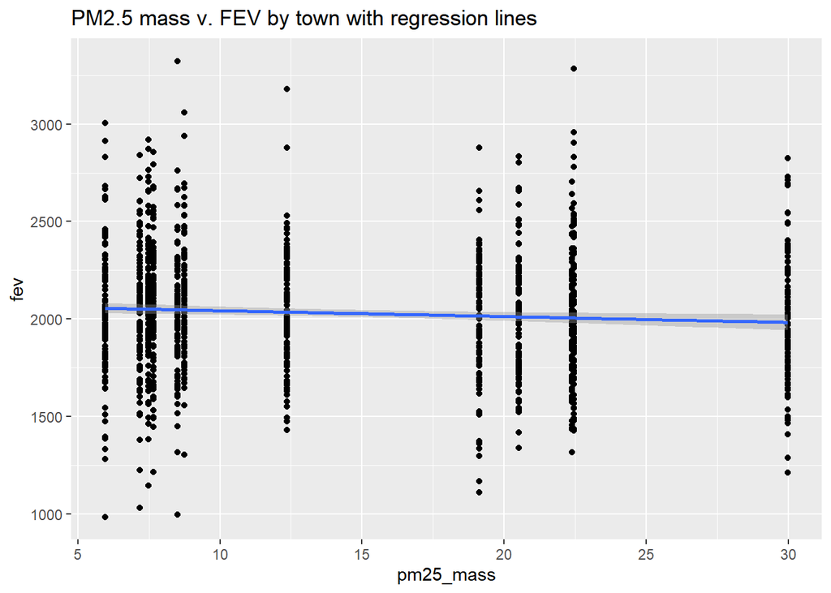

```r
merged %>%
  ggplot(mapping = aes(x=pm25_mass, y=fev))+
  geom_point()+
  stat_smooth(method=lm)+
  labs(title = "PM2.5 mass v. FEV by town with regression lines")
```

- Since pm2.5 is only reported per town, it’s hard to tell directly from this graph whether PM2.5 mass is associated with FEV.

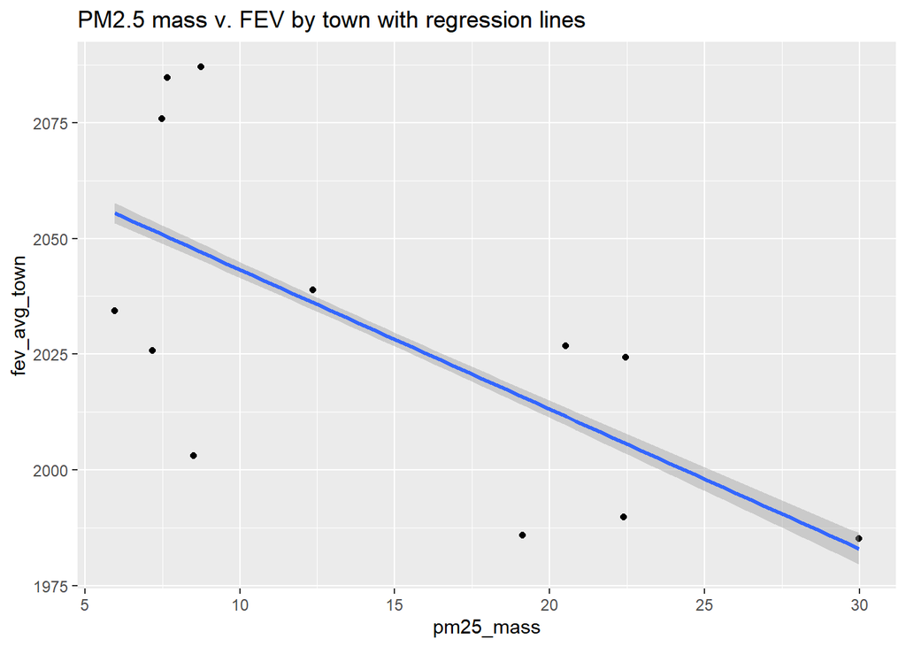

```r
merged[, fev_avg_town := mean(fev, na.rm = TRUE), by = .(townname)]
merged %>%
  ggplot(mapping = aes(x=pm25_mass, y=fev_avg_town))+
  geom_point()+
  stat_smooth(method=lm)+
  labs(title = "PM2.5 mass v. FEV by town with regression lines")
```

- If we use the town average FEV to draw the graph instead, the PM2.5 mass shows negative association with FEV.